# Walmart Sales Data Exploration - MySQL

Kevin Folkes

2024-09-01

[figure not shown]

- Investigate the data and measure the statistics.
- Analyze measurements to draw insights and possible reccommendations.

## Investegating the Data

```python
%%sql
SELECT
  *
FROM
  projects.walmart_sales;
```

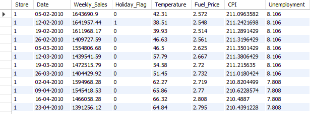

```python
%%sql
-- Check columns
SHOW COLUMNS
FROM
  projects.walmart_sales;
```

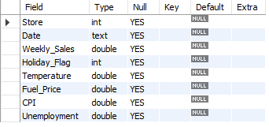

# Date column appears to be text format.  
We are going to format the date column

```python
%%sql
SELECT
  str_to_date (`Date`, '%d-%m-%Y') AS formatted_date
FROM
  projects.walmart_sales;

UPDATE projects.walmart_sales
SET
  `Date` = str_to_date (`Date`, '%d-%m-%Y');
```

[figure not shown]

### Checking for duplicates

- We need to create a unique_id column given as there is no PRIMARY KEY in this dataset.

```python
%%sql
WITH
  CTE_dup_check AS (
    SELECT
      *,
      ROW_NUMBER() OVER (
        PARTITION BY
          unique_id
        ORDER BY
          unique_id
      ) AS row_num
    FROM
      (
        SELECT
          *,
          CONCAT (Store, '-', `Date`) AS unique_id
        FROM
          projects.walmart_sales
      ) AS unique_table
  )
SELECT
  *
FROM
  CTE_dup_check
WHERE
  row_num > 1;
```

- 0 rows were returned, there are no duplicates in this dataset

### Checking for nulls

```python
%%sql
SELECT
  SUM(
    CASE
      WHEN Store IS NULL THEN 1
      ELSE 0
    END
  ) AS Store_null_count,
  SUM(
    CASE
      WHEN `Date` IS NULL THEN 1
      ELSE 0
    END
  ) AS Date_null_count,
  SUM(
    CASE
      WHEN Weekly_Sales IS NULL THEN 1
      ELSE 0
    END
  ) AS Weekly_Sales_null_count,
  SUM(
    CASE
      WHEN Holiday_Flag IS NULL THEN 1
      ELSE 0
    END
  ) AS Holiday_Flag_null_count,
  SUM(
    CASE
      WHEN Temperature IS NULL THEN 1
      ELSE 0
    END
  ) AS Temperature_null_count,
  SUM(
    CASE
      WHEN Fuel_Price IS NULL THEN 1
      ELSE 0
    END
  ) AS Fuel_Price_null_count,
  SUM(
    CASE
      WHEN CPI IS NULL THEN 1
      ELSE 0
    END
  ) AS CPI_null_count,
  SUM(
    CASE
      WHEN Unemployment IS NULL THEN 1
      ELSE 0
    END
  ) AS Unemployment_null_count
FROM
  projects.walmart_sales;
```

- 0 returned for all columns, there are no nulls in this dataset

# Measure the Statistics

#### What is the date range?

```python
%%sql
SELECT
  MIN(YEAR (`DATE`)) AS min_year,
  MAX(YEAR (`DATE`)) AS max_year
FROM
  projects.walmart_sales;
```

- dataset spans from 2010 - 2012

#### What is the higest, lowest and avareage weekly_sales?

```python
%%sql
SELECT
  MAX(Weekly_Sales) AS max_week_sales,
  MIN(Weekly_Sales) AS min_week_sales,
  ROUND(AVG(Weekly_Sales), 2) AS avg_week_sales
FROM
  projects.walmart_sales;
```

# Analyze

#### Which Store has the highest avg sales?

```python
%%sql
SELECT
  Store,
  MAX(Weekly_Sales) AS max_week_sales,
  MIN(Weekly_Sales) AS min_week_sales,
  ROUND(AVG(Weekly_Sales), 2) avg_week_sales,
  DENSE_RANK() OVER (
    ORDER BY
      AVG(Weekly_Sales) DESC
  ) AS store_avg_sales_rank
FROM
  projects.walmart_sales
GROUP BY
  Store;
```

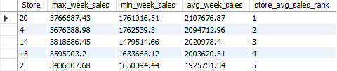

```python
%%sql
SELECT
  Store,
  MAX(Weekly_Sales) AS max_week_sales,
  MIN(Weekly_Sales) AS min_week_sales,
  ROUND(AVG(Weekly_Sales), 2) avg_week_sales,
  DENSE_RANK() OVER (
    ORDER BY
      AVG(Weekly_Sales) DESC
  ) AS store_avg_sales_rank
FROM
  projects.walmart_sales
GROUP BY
  Store
ORDER BY
  store_avg_sales_rank DESC;
```

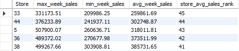

#### Which month is the best in terms of avraege sales per store?

```python
%%sql
WITH
  CTE_best_month AS (
    SELECT
      Store,
      MONTHNAME (`Date`) AS months,
      MONTH (`Date`) AS month_num,
      ROUND(SUM(Weekly_Sales), 2) total_month_sales,
      ROUND(AVG(Weekly_Sales), 2) AS avg_month_sales,
      DENSE_RANK() OVER (
        PARTITION BY
          Store
        ORDER BY
          AVG(Weekly_Sales) DESC
      ) AS store_rank
    FROM
      projects.walmart_sales
    GROUP BY
      months,
      month_num,
      Store
  )
SELECT
  Store,
  months,
  avg_month_sales
FROM
  CTE_best_month
WHERE
  store_rank = 1
ORDER BY
  month_num ASC,
  avg_month_sales DESC;
```

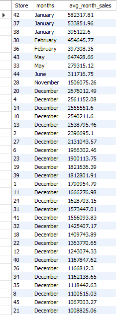

#### How does Holidays affect weekly sale?

```python
%%sql
SELECT
  ROUND(
    (
      SELECT
        SUM(Weekly_Sales)
      FROM
        projects.walmart_sales
      WHERE
        Holiday_Flag = 1
    ) / SUM(Weekly_Sales) * 100,
    2
  ) holiday_sales_impact
FROM
  projects.walmart_sales;
```

#### Does Temperature have any affect on sales?

- To better understand the Temperature, it will be converted to celcius
- Celcius = (Fahrenheit - 32) * 0.5556

```python
%%sql
-- adding a decimal column to store the temp celcius.
ALTER TABLE projects.walmart_sales
ADD COLUMN Temperature_Celcius DECIMAL(4, 1);
```

```python
%%sql
-- updating the temp celcuis column to with converted results from the fahrenheit column.
UPDATE projects.walmart_sales
SET
  Temperature_Celcius = ROUND((Temperature - 32) * 0.5556, 1);
```

```python
%%sql
SELECT
  Temperature AS Fahrenheit,
  Temperature_Celcius AS Celcius
FROM
  projects.walmart_sales;
```

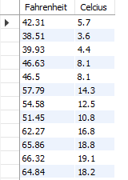

```python
%%sql
SELECT
  ROUND(
    (
      MIN(Temperature_Celcius) + MAX(Temperature_Celcius)
    ) / 2,
    1
  ) AS temp_median
FROM
  projects.walmart_sales;
```

- Storing the median result in a variable:

```python
%%sql
SET @temp_median = (
 SELECT ROUND((MIN(Temperature_Celcius) + MAX(Temperature_Celcius)) / 2, 1)
 FROM projects.walmart_sales);
```

```python
%%sql
SELECT
  ROUND(SUM(high_low_avg) / COUNT(high_low_avg) * 100, 2) AS sales_higher_than_avg
FROM
  (
    SELECT
      Weekly_Sales,
      CASE
        WHEN (
          SELECT
            AVG(Weekly_Sales)
          FROM
            projects.walmart_sales
        ) > Weekly_Sales THEN 1
        ELSE 0
      END AS high_low_avg,
      Temperature_Celcius
    FROM
      projects.walmart_sales
    ORDER BY
      Temperature_Celcius DESC
  ) AS temperature_table
WHERE
  Temperature_Celcius < 0;
```

#### How does CPI relates to Sales?

```python
%%sql
SELECT
  Weekly_Sales,
  ROUND(CPI, 1) CPI
FROM
  projects.walmart_sales;
```

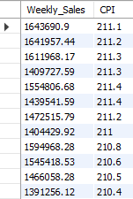

```python
%%sql
WITH
  CTE_CPI AS (
    SELECT
      *,
      LAG (avg_sales) OVER () previous_sales,
      avg_sales - LAG (avg_sales) OVER () AS diff
    FROM
      (
        SELECT DISTINCT
          ROUND(CPI) _CPI,
          ROUND(AVG(Weekly_Sales)) AS avg_sales
        FROM
          projects.walmart_sales
        GROUP BY
          _CPI
        ORDER BY
          1
      ) cpi_table
  )
SELECT
  ROUND(
    AVG(
      CASE
        WHEN diff < 0 THEN 1
        ELSE 0
      END
    ) * 100,
    2
  ) AS CPI_impact
FROM
  CTE_CPI;
```

#### How does unemployment relate to Sales?

```python
%%sql
SELECT
  COUNT(DISTINCT (ROUND(Unemployment, 1))) -- 74 unique values for unemployment
FROM
  projects.walmart_sales;
```

```python
%%sql
WITH
  CTE_unemployment AS (
    SELECT
      (ROUND(Unemployment, 1)) AS uemployeement,
      ROUND(AVG(Weekly_Sales)) AS avg_sales_per_unemployeemtn,
      LAG (ROUND(AVG(Weekly_Sales))) OVER (
        ORDER BY
          ROUND(Unemployment, 1)
      ) AS previous_avg_sales,
      ROUND(AVG(Weekly_Sales)) - LAG (ROUND(AVG(Weekly_Sales))) OVER (
        ORDER BY
          ROUND(Unemployment, 1)
      ) diff
    FROM
      projects.walmart_sales
    GROUP BY
      uemployeement
    ORDER BY
      1,
      2
  )
SELECT
  ROUND(
    (
      SUM(
        CASE
          WHEN diff < 0 THEN 1
          ELSE 0
        END
      ) / COUNT(diff)
    ) * 100,
    2
  ) AS percentage_sales_decrease_when_unemployment_increases
FROM
  CTE_unemployment;
```

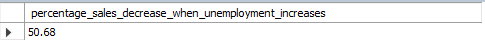

# Conclusion:

- The dataset is fairly clean and retiable with no duplicates and no nulls.
- Data ranges from 2010 - 2012 (3 years)
- Max sales is 3.8 mil and min sales is 209.9k. Average sales 1.07 mil
- TOP stores with the hihest average sakes (20,4,14,13 & 2)
- Lowest stores based on average sales are (33,44,5,36 & 38)
- December is largely the most profitable month for store slaes
- Stores with the lowest sales do not have december as their most profitable month.
- Holiday weeks account for 7.5% of all sales
- Temperature don't necessarily impact sales when evenly split. However, when below freezing sales to increase (this is most likely to be the impact of holiday sales)
- Consumer Price Index does not directly impact sales, about 54% of the time it raises, average sales decrease. This should be explore more in a visual medium.
- 50% of the time unemployment increases, sales decrease.